# Data Analysis Practice 01 | R Programming | 2022 Fall

Lilian

# Clean environment & Load Libraries

```r
# Clean environment
rm(list=ls())

# Set the working Directory
setwd("D:/WorkSpace/RWorkSpace/HWDemo")

# Load libraries
library(tidyverse)
library(datasets)
library('ggplot2')
library (MASS)
library (ISLR)
```

# 2.1 Data analysis based on the iris sample dataset

Load the iris sample dataset into R using a dataframe (it is a built-in dataset). Create a boxplot of each of the 4 features, and highlight the feature with the largest empirical IQR. Calculate the parametric standard deviation for each feature - do your results agree with the empirical values? Use the ggplot2 library from CRAN to create a colored boxplot for each feature, with a box-whisker per flower species. Which flower type exhibits a significantly different Petal Length/Width once it is separated from the other classes?

```r
# Load the iris sample dataset into R
iris = data.frame(iris)
head(iris)
```

|  | Sepal.Length | Sepal.Width | Petal.Length | Petal.Width | Species |
| --- | --- | --- | --- | --- | --- |
| 1 | 5.1 | 3.5 | 1.4 | 0.2 | setosa |
| 2 | 4.9 | 3.0 | 1.4 | 0.2 | setosa |
| 3 | 4.7 | 3.2 | 1.3 | 0.2 | setosa |
| 4 | 4.6 | 3.1 | 1.5 | 0.2 | setosa |
| 5 | 5.0 | 3.6 | 1.4 | 0.2 | setosa |
| 6 | 5.4 | 3.9 | 1.7 | 0.4 | setosa |

```r
str(iris)
```

```
'data.frame':   150 obs. of  5 variables:
 $ Sepal.Length: num  5.1 4.9 4.7 4.6 5 5.4 4.6 5 4.4 4.9 ...
 $ Sepal.Width : num  3.5 3 3.2 3.1 3.6 3.9 3.4 3.4 2.9 3.1 ...
 $ Petal.Length: num  1.4 1.4 1.3 1.5 1.4 1.7 1.4 1.5 1.4 1.5 ...
 $ Petal.Width : num  0.2 0.2 0.2 0.2 0.2 0.4 0.3 0.2 0.2 0.1 ...
 $ Species     : Factor w/ 3 levels "setosa","versicolor",..: 1 1 1 1 1 1 1 1 1 1 ...
```

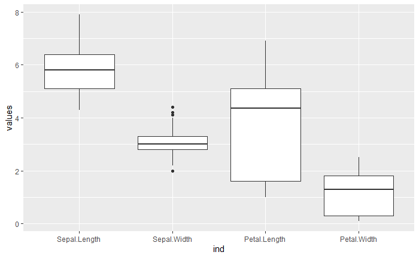

```r
# Create a boxplot of each of the 4 features
# boxplot(iris, xlab = "Attributes", ylab = "Values", main = "Iris")
ggplot(data=stack(iris), mapping = aes(x=ind, y = values)) + geom_boxplot()
```

```r
# IQR of each of the 4 features
SepalLength <- iris$Sepal.Length
SepalWidth <- iris$Sepal.Width
PetalLength <- iris$Petal.Length
PetalWidth <- iris$Petal.Width

cat("\nIQR of SepalLength: ", IQR(SepalLength))
```

```
IQR of SepalLength:  1.3
```

```r
cat("\nIQR of SepalWidth: ", IQR(SepalWidth))
```

```
IQR of SepalWidth:  0.5
```

```r
cat("\nIQR of PetalLength: ", IQR(PetalLength))
```

```
IQR of PetalLength:  3.5
```

```r
cat("\nIQR of PetalWidth: ", IQR(PetalWidth))
```

```
IQR of PetalWidth:  1.5
```

```r
cat("\nThe feature with the largest empirical IQR is PetalLength = 3.5")
```

```
The feature with the largest empirical IQR is PetalLength = 3.5
```

```r
# Highlight the feature with the largest empirical IQR
cat("\nHighlight the feature with the largest empirical IQR.")
```

```
Highlight the feature with the largest empirical IQR.
```

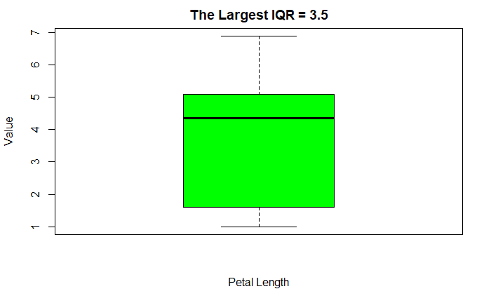

```r
boxplot(iris$Petal.Length, main="The Largest IQR = 3.5", xlab="Petal Length", ylab ="Value", col="green" )
```

```r
par(mfrow=c(2,2))

# Calculate the parametric standard deviation
cat("The standard deviation of iris SepalLength is: ", sd(SepalLength), "\n")
```

```
The standard deviation of iris SepalLength is:  0.8280661
```

```r
cat("The standard deviation of iris SepalWidth is: ", sd(SepalWidth), "\n")
```

```
The standard deviation of iris SepalWidth is:  0.4358663
```

```r
cat("The standard deviation of iris PetalLength is: ", sd(PetalLength), "\n")
```

```
The standard deviation of iris PetalLength is:  1.765298
```

```r
cat("The standard deviation of iris PetalWidth is: ", sd(PetalWidth), "\n")
```

```
The standard deviation of iris PetalWidth is:  0.7622377
```

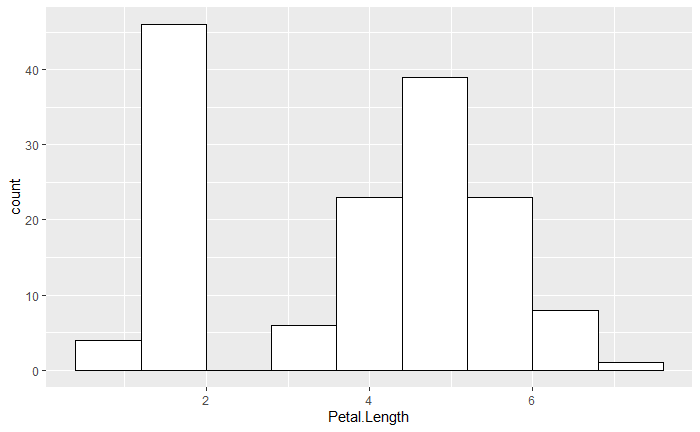

```r
ggplot(iris, aes(x=Petal.Length)) +
geom_histogram(color="black", fill="white", binwidth = .8)
```

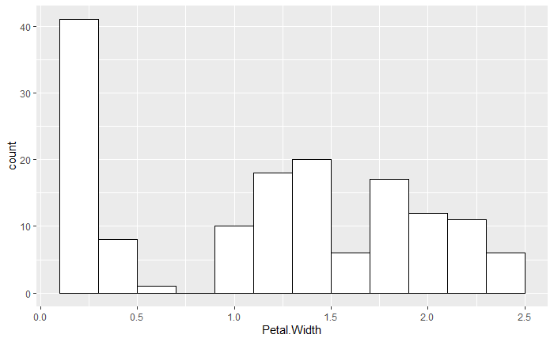

```r
ggplot(iris, aes(x=Petal.Width)) +
geom_histogram(color="black", fill="white", binwidth = .2)
```

Do your results agree with the empirical values?

My answer:

The results don’t agree with the empirical values. The standard deviation values shows that Petal Length and Petal Width don’t follow a normal distribution.

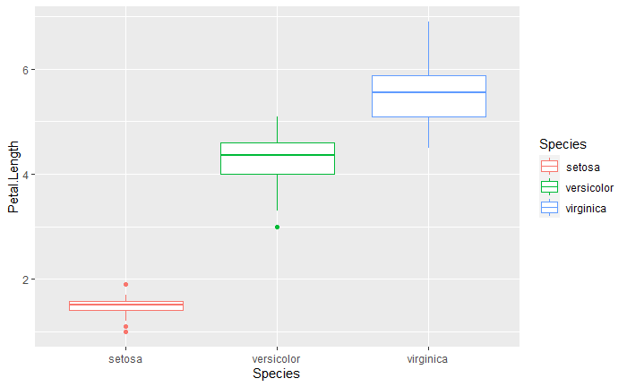

```r
par(mfrow=c(2,2))

# Use the ggplot2 library from CRAN to create a colored boxplot for each feature, with a box-whisker per flower species.
ggplot(data = iris) + geom_boxplot(mapping = aes(x = Species, y = Petal.Length, color = Species))
```

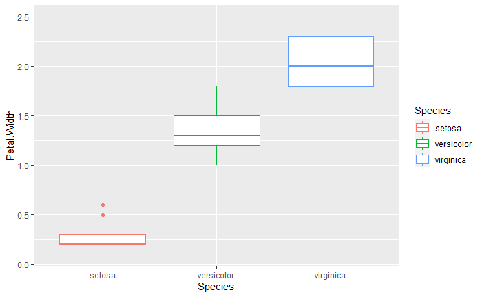

```r
ggplot(data = iris) + geom_boxplot(mapping = aes(x = Species, y = Petal.Width, color = Species))
```

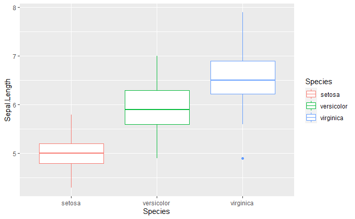

```r
ggplot(data = iris) + geom_boxplot(mapping = aes(x = Species, y = Sepal.Length, color = Species))
```

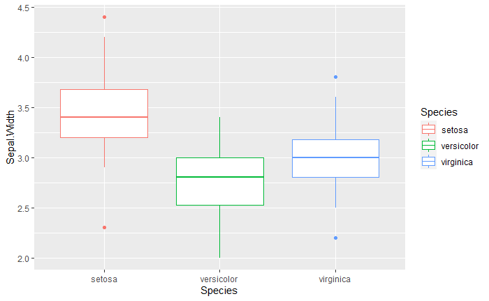

```r
ggplot(data = iris) + geom_boxplot(mapping = aes(x = Species, y = Sepal.Width, color = Species))
```

Which flower type exhibits a significantly different Petal Length/Width once it is separated from the other classes??

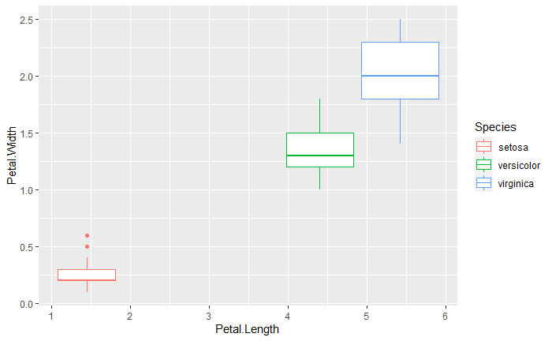

```r
ggplot(data=iris) + geom_boxplot(mapping = aes(x=Petal.Length, y=Petal.Width, color = Species))
```

overlap:similar range

My answer: The range and IQR of setosa between the Petal Length and Petal Width is significantly different.

# 2.2 Data analysis based on the trees sample dataset

Load the trees sample dataset into R using a dataframe (it is a built-in dataset), and produce a 5-number summary of each feature. Create a histogram of each variable - which variables appear to be normally distributed based on visual inspection? Do any variables exhibit positive or negative skewness? Install the moments library from CRAN use the skewness function to calculate the skewness of each variable. Do the values agree with the visual inspection?

## Load Data

```r
# Load the trees sample dataset into R and produce a 5-number summary of each feature
trees = data.frame(trees)
trees
```

| Girth | Height | Volume |
| --- | --- | --- |
| 8.3 | 70 | 10.3 |
| 8.6 | 65 | 10.3 |
| 8.8 | 63 | 10.2 |
| 10.5 | 72 | 16.4 |
| 10.7 | 81 | 18.8 |
| 10.8 | 83 | 19.7 |
| 11.0 | 66 | 15.6 |
| 11.0 | 75 | 18.2 |
| 11.1 | 80 | 22.6 |
| 11.2 | 75 | 19.9 |

[output cut: 21 more lines]

```r
str(trees)
```

```
'data.frame':   31 obs. of  3 variables:
 $ Girth : num  8.3 8.6 8.8 10.5 10.7 10.8 11 11 11.1 11.2 ...
 $ Height: num  70 65 63 72 81 83 66 75 80 75 ...
 $ Volume: num  10.3 10.3 10.2 16.4 18.8 19.7 15.6 18.2 22.6 19.9 ...
```

## Data Processing

### produce a 5-number summary of each feature

```r
# produce a 5-number summary of each feature
cat("A five number summary of Girth is", fivenum(trees$Girth), "\n")
```

```
A five number summary of Girth is 8.3 11.05 12.9 15.25 20.6
```

```r
cat("A five number summary of Height is", fivenum(trees$Height), "\n")
```

```
A five number summary of Height is 63 72 76 80 87
```

```r
cat("A five number summary of Height is", fivenum(trees$Volume), "\n")
```

```
A five number summary of Height is 10.2 19.4 24.2 37.3 77
```

### Output a 5-number summary of each feature in detail

```r
cat("Output a 5-number summary of each feature in detail： ", "\n")
```

```
Output a 5-number summary of each feature in detail:
```

```r
cat("summary(trees$Girth)： ", "\n")
```

```
summary(trees$Girth):
```

```r
summary(trees$Girth)
```

```
   Min. 1st Qu.  Median    Mean 3rd Qu.    Max.
   8.30   11.05   12.90   13.25   15.25   20.60
```

```r
cat("summary(trees$Height): ", "\n")
```

```
summary(trees$Height):
```

```r
summary(trees$Height)
```

```
   Min. 1st Qu.  Median    Mean 3rd Qu.    Max.
     63      72      76      76      80      87
```

```r
cat("summary(trees$Volume): ", "\n")
```

```
summary(trees$Volume):
```

```r
summary(trees$Volume)
```

```
   Min. 1st Qu.  Median    Mean 3rd Qu.    Max.
  10.20   19.40   24.20   30.17   37.30   77.00
```

### Create a histogram of each variable

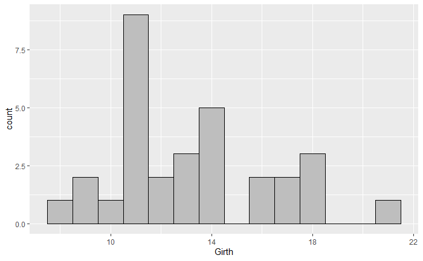

```r
# Create a histogram of each variable
# which variables appear to be normally distributed based on visual inspection?
ggplot(trees, aes(x = Girth)) + geom_histogram(color = "black", fill = "grey", binwidth = 1)
```

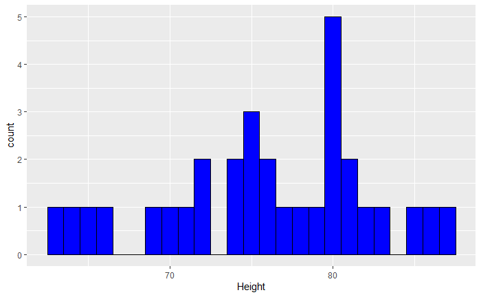

```r
ggplot(trees, aes(x = Height)) + geom_histogram(color = "black", fill = "blue", binwidth = 1)
```

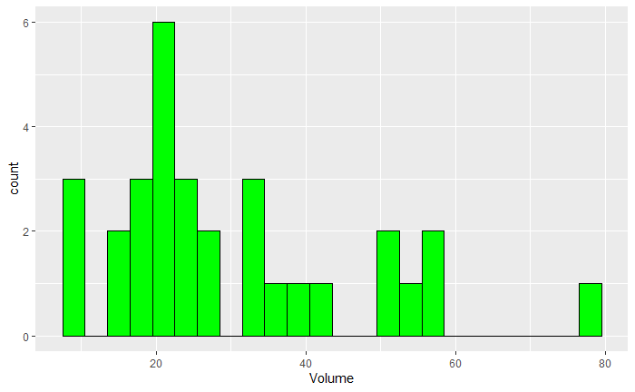

```r
ggplot(trees, aes(x = Volume)) + geom_histogram(color = "black", fill = "green", binwidth = 3)
```

## Data Analysis

```r
# Do any variables exhibit positive or negative skewness?
# Do the values agree with the visual inspection?

# install.packages("moments")
library("moments")

cat("\nSkewness of Girth:",skewness(trees$Girth))
```

```
Skewness of Girth: 0.5010559
```

```r
cat("\nSkewness of Height:",skewness(trees$Height))
```

```
Skewness of Height: -0.3568773
```

```r
cat("\nSkewness of Height:",skewness(trees$Volume))
```

```
Skewness of Height: 1.013274
```

My analysis:

Compared to the other variables, “Height” appear to be normally distributed. It’s close to a good normal distribution.

“Girth” and “Volume” exhibit positive skewness. “Height” appears to be slightly negatively skewed. The values correspond with the visual histogram inspection.

# 2.3 Data analysis based on the auto-mpg sample dataset

## Load Data

```r
# Load the auto-mpg sample dataset from the UCI Machine Learning Repository (auto-mpg.data) into R using a dataframe

url = "https://archive.ics.uci.edu/ml/machine-learning-databases/auto-mpg/auto-mpg.data"

df <- read.csv(file = url,
               header = FALSE,
               sep = "",
               as.is = T,
               stringsAsFactors = F,
               col.names =  c("mpg","cylinders","displacement","horsepower","weight","acceleration", "model year", "origin", "car name"))

str(df)
```

```
'data.frame':   398 obs. of  9 variables:
 $ mpg         : num  18 15 18 16 17 15 14 14 14 15 ...
 $ cylinders   : int  8 8 8 8 8 8 8 8 8 8 ...
 $ displacement: num  307 350 318 304 302 429 454 440 455 390 ...
 $ horsepower  : chr  "130.0" "165.0" "150.0" "150.0" ...
 $ weight      : num  3504 3693 3436 3433 3449 ...
 $ acceleration: num  12 11.5 11 12 10.5 10 9 8.5 10 8.5 ...
 $ model.year  : int  70 70 70 70 70 70 70 70 70 70 ...
 $ origin      : int  1 1 1 1 1 1 1 1 1 1 ...
 $ car.name    : chr  "chevrolet chevelle malibu" "buick skylark 320" "plymouth satellite" "amc rebel sst" ...
```

```r
head(df)
```

|  | mpg | cylinders | displacement | horsepower | weight | acceleration | model.year | origin | car.name |
| --- | --- | --- | --- | --- | --- | --- | --- | --- | --- |
| 1 | 18 | 8 | 307 | 130.0 | 3504 | 12.0 | 70 | 1 | chevrolet chevelle malibu |
| 2 | 15 | 8 | 350 | 165.0 | 3693 | 11.5 | 70 | 1 | buick skylark 320 |
| 3 | 18 | 8 | 318 | 150.0 | 3436 | 11.0 | 70 | 1 | plymouth satellite |
| 4 | 16 | 8 | 304 | 150.0 | 3433 | 12.0 | 70 | 1 | amc rebel sst |
| 5 | 17 | 8 | 302 | 140.0 | 3449 | 10.5 | 70 | 1 | ford torino |
| 6 | 15 | 8 | 429 | 198.0 | 4341 | 10.0 | 70 | 1 | ford galaxie 500 |

## Data Processing

```r
# Use the as.numeric casting function to obtain the column as a numeric vector,
df$horsepower <-  as.numeric(df$horsepower)
# df$horsepower

horsePowerBase <- df$horsepower

# Orignial Mean
cat("Orignial Mean is", mean(df$horsepower, na.rm = TRUE), "\n")
```

```
Orignial Mean is 104.4694
```

```r
horse_NA_median <- df$horsepower

# Replace all NA values with the median
horse_NA_median[which(is.na(df$horsepower))] <- median(df$horsepower, na.rm =TRUE)
```

```r
# Mean when NA = median
cat("Mean when NA = median is", mean(horse_NA_median))
```

```
Mean when NA = median is 104.304
```

```r
# How does this affec the value obtained for the mean vs the original mean when the records were ignored?
```

The original mean is 104.4694 which is a little greater than the mean after we use the median to fill in NA values.

```r
# Load the Boston sample dataset into R using a dataframe
Boston <- data.frame(Boston)
head(Boston)
```

|  | crim | zn | indus | chas | nox | rm | age | dis | rad | tax | ptratio | black | lstat | medv |
| --- | --- | --- | --- | --- | --- | --- | --- | --- | --- | --- | --- | --- | --- | --- |
| 1 | 0.00632 | 18 | 2.31 | 0 | 0.538 | 6.575 | 65.2 | 4.0900 | 1 | 296 | 15.3 | 396.90 | 4.98 | 24.0 |
| 2 | 0.02731 | 0 | 7.07 | 0 | 0.469 | 6.421 | 78.9 | 4.9671 | 2 | 242 | 17.8 | 396.90 | 9.14 | 21.6 |
| 3 | 0.02729 | 0 | 7.07 | 0 | 0.469 | 7.185 | 61.1 | 4.9671 | 2 | 242 | 17.8 | 392.83 | 4.03 | 34.7 |
| 4 | 0.03237 | 0 | 2.18 | 0 | 0.458 | 6.998 | 45.8 | 6.0622 | 3 | 222 | 18.7 | 394.63 | 2.94 | 33.4 |
| 5 | 0.06905 | 0 | 2.18 | 0 | 0.458 | 7.147 | 54.2 | 6.0622 | 3 | 222 | 18.7 | 396.90 | 5.33 | 36.2 |
| 6 | 0.02985 | 0 | 2.18 | 0 | 0.458 | 6.430 | 58.7 | 6.0622 | 3 | 222 | 18.7 | 394.12 | 5.21 | 28.7 |

```r
names(Boston)
```

```
 [1] "crim"    "zn"      "indus"   "chas"    "nox"     "rm"      "age"     "dis"     "rad"
[10] "tax"     "ptratio" "black"   "lstat"   "medv"
```

```r
?Boston
```

## Fit a regression

```r
# Use lm to fit a regression between medv and lstat - plot the resulting fit and show a plot of fitted values vs. residuals

# medv: median value of owner-occupied homes in \$1000s.
# lstat: lower status of the population (percent).
lm.fit <- lm(medv~lstat, data=Boston )
lm.fit
```

```
Call:
lm(formula = medv ~ lstat, data = Boston)

Coefficients:
(Intercept)        lstat
      34.55        -0.95
```

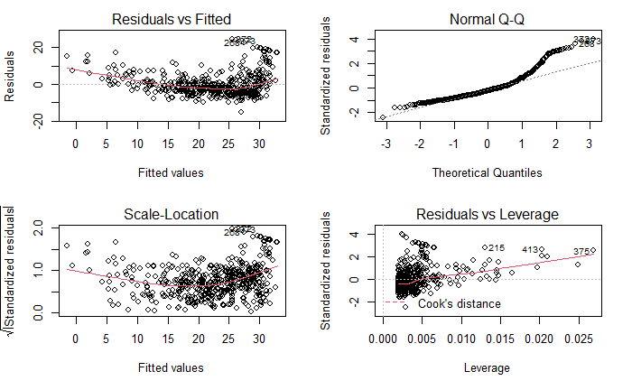

```r
par(mfrow = c(2,2))
# par(mfrow = c(1,1))
plot(lm.fit)
```

```r
summary(lm.fit)
```

```
Call:
lm(formula = medv ~ lstat, data = Boston)

Residuals:
    Min      1Q  Median      3Q     Max
-15.168  -3.990  -1.318   2.034  24.500

Coefficients:
            Estimate Std. Error t value Pr(>|t|)
(Intercept) 34.55384    0.56263   61.41   <2e-16 ***
lstat       -0.95005    0.03873  -24.53   <2e-16 ***
---
Signif. codes:  0 ‘***’ 0.001 ‘**’ 0.01 ‘*’ 0.05 ‘.’ 0.1 ‘ ’ 1

Residual standard error: 6.216 on 504 degrees of freedom
Multiple R-squared:  0.5441,    Adjusted R-squared:  0.5432
F-statistic: 601.6 on 1 and 504 DF,  p-value: < 2.2e-16
```

## Obtain confidence intervals

```r
# Use the predict function to calculate values response values for lstat of 5, 10, and 15 - obtain confidence intervals as well as prediction intervals for the results

# lstat: lower status of the population (percent).
cat("Calculate values response values for lstat of 5, 10, and 15 - obtain confidence intervals", "\n")
```

```
Calculate values response values for lstat of 5, 10, and 15 - obtain confidence intervals
```

```r
predict(lm.fit, data.frame(lstat=c(5, 10, 15)), interval ="confidence")
```

```
       fit      lwr      upr
1 29.80359 29.00741 30.59978
2 25.05335 24.47413 25.63256
3 20.30310 19.73159 20.87461
```

```r
cat("Calculate values response values for lstat of 5, 10, and 15 - obtain prediction intervals", "\n")
```

```
Calculate values response values for lstat of 5, 10, and 15 - obtain prediction intervals
```

```r
predict(lm.fit, data.frame(lstat=c(5, 10, 15)), interval ="prediction")
```

```
       fit       lwr      upr
1 29.80359 17.565675 42.04151
2 25.05335 12.827626 37.27907
3 20.30310  8.077742 32.52846
```

## Modify the regression

```r
# Modify the regression to include lstat2 (as well lstat itself) and compare the R2 between the linear and non-linear fit - use ggplot2 and stat smooth to plot the relationship.

intercept <- coef(lm.fit)[1]
slope <- coef(lm.fit)[2]

fit2 <- lm(medv ~ lstat + I(lstat ^2), data=Boston)
summary(fit2)
```

```
Call:
lm(formula = medv ~ lstat + I(lstat^2), data = Boston)

Residuals:
     Min       1Q   Median       3Q      Max
-15.2834  -3.8313  -0.5295   2.3095  25.4148

Coefficients:
             Estimate Std. Error t value Pr(>|t|)
(Intercept) 42.862007   0.872084   49.15   <2e-16 ***
lstat       -2.332821   0.123803  -18.84   <2e-16 ***
I(lstat^2)   0.043547   0.003745   11.63   <2e-16 ***
---
Signif. codes:  0 ‘***’ 0.001 ‘**’ 0.01 ‘*’ 0.05 ‘.’ 0.1 ‘ ’ 1

Residual standard error: 5.524 on 503 degrees of freedom
Multiple R-squared:  0.6407,    Adjusted R-squared:  0.6393
F-statistic: 448.5 on 2 and 503 DF,  p-value: < 2.2e-16
```

## Predict & Data Analysis

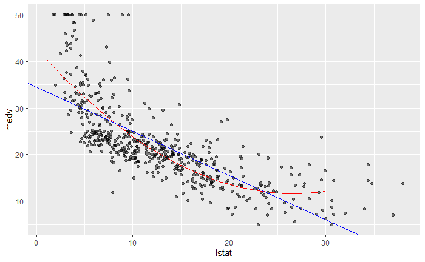

```r
predictions <- data.frame(pred = predict(fit2, data.frame(lstat=1:30)))

ggplot(Boston, aes(x = lstat, y = medv)) + geom_point(alpha = 0.5) +
geom_line(data = predictions, aes(x = 1:dim(predictions)[1], y = pred), color = "red") +
geom_abline(intercept = intercept, slope = slope, color = "blue")
```

```r
anova(fit2, lm.fit)
```

```
Analysis of Variance Table

Model 1: medv ~ lstat + I(lstat^2)
Model 2: medv ~ lstat
  Res.Df   RSS Df Sum of Sq     F    Pr(>F)
1    503 15347
2    504 19472 -1   -4125.1 135.2 < 2.2e-16 ***
---
Signif. codes:  0 ‘***’ 0.001 ‘**’ 0.01 ‘*’ 0.05 ‘.’ 0.1 ‘ ’ 1
```

My answer:

Yes. There is a possible non-linear relationship between the predictor and response.

According to the outputs of summary() and the plots, we see:

1. the R-squared value of the quadratic model is higher than the R-squared of the linear model. The R square value close to 1 indicates that the model explains a large portion of the variance in the response variable.
2. the residual standard error of the quadratic model is smaller than the residual standard error of the linear model. The smaller the residual standard error, the better a regression model fits a data set.
3. The read spline on the plot appear to fit data better.

Hence, the non-linear fit is better than the linear fit.